# Adding covariates to a linear model

In its most general sense, **Covariates** are simply the $X$ variables in a statistical model. With data from experiments, “covariates” more typically refers to $X$ variables that are added to a model to increase precision of the treatment effects. In observational designs, covariates might be added to a model to 1) increase predictive ability, 2) because the researcher is interested in specific conditional effects, or 3) to eliminate confounding. These are discussed in later chapters. In this chapter, the covariate added to a linear model is a continous variable. Nothing is fundamentally different if the covariate added is categorical ($Sex$ is a common categorical covariate).

## Adding covariates can increases the precision of the effect of interest

I use fake data to introduce the concept of **statistical elimination** of a **covariate** in a statistical model. Here I am modeling the effect of a new drug on blood LDL-C levels. LDL is a kind of lipoprotein, which are particles in the blood that transport fats and cholesterol to and from different tissues. LDL-C is cholesterol associated with LDL particles. LDL-C is considered “bad cholesterol” because LDL is believed to transport cholesterol and other lipids to arterial walls, which is the basis for atherosclerosis.

Thirty applied biostats students are recruited and are randomly assigned to either the “placebo” treatment level or “drug” treatment level. The response is blood LDL-C concentration. The drug manufacturer wants a measure of the effect of the new drug on ldlc.

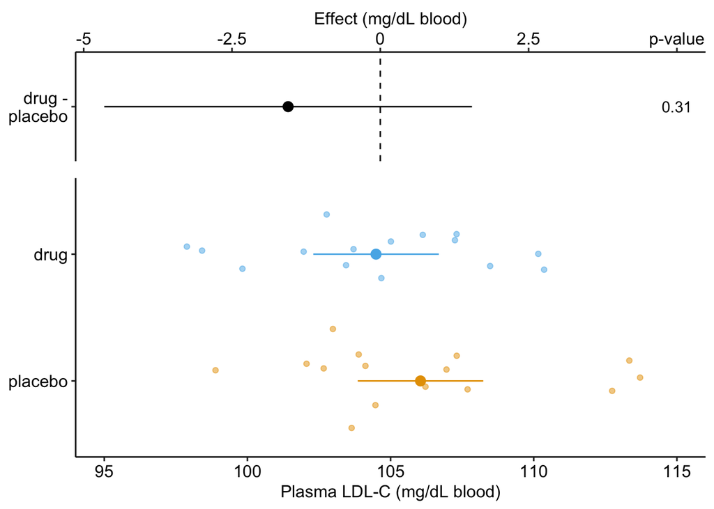

Effect of drug therapy on plasma LDL-C.

The linear model fit to the simulated LDL-C data is

$$\begin{equation}
ldlc = \beta_0 + \beta_1 treatment_{drug} + \varepsilon
(\#eq:cov-no-cov)
\end{equation}$$

where $treatment_{drug}$ is the dummy variable, which is set to 0 when $treatment = \mathrm{''placebo''}$ and to 1 when $treatment = \mathrm{''drug''}$.

The coefficient table is

```
##               Estimate Std. Error t value Pr(>|t|)   2.5 %  97.5 %
## (Intercept)    106.045      1.070  99.111    0.000 103.854 108.237
## treatmentdrug   -1.554      1.513  -1.027    0.313  -4.654   1.546
```

The response-effect plot shows large overlap in the LDL-C response and treatment effect that is small relative to the noise. “No effect of the drug ($p = .31$)” is an incorrect interpretation of the *p*-value of the significance test of the estimate of $\beta_1$. A better interpretation is, the estimated effect is -1.6 but everything from large, negative effects to moderate positive effects are consistent with the data.

As expert biologists, we know that LDL-C is strongly correlated with age and there is a large range in age among the Applied Bistats students. If age contributes to a large fraction of the variance in LDL-C among applied biostats students, then age-related variance *might* mask the effect of the drug. Here is a plot of LDL-C vs. age, with treatment assignment color coded. Remember, these are the exact same values of LDL-C as in figure @ref(fig:cov-harrelplot) above.

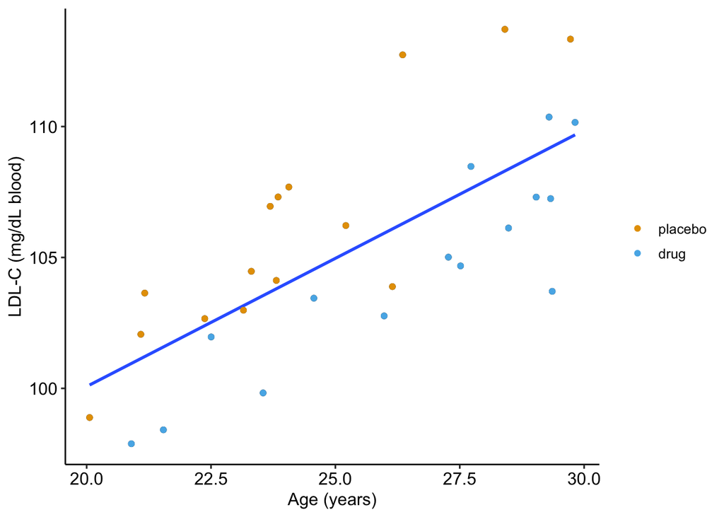

Linear regression of $ldlc$ on age fit to the fake LDL-C data. The points are color coded by treatment.

The regression line is the fit of the linear model

$$\begin{equation}
ldlc = \beta_0 + \beta_1 age + \varepsilon
(\#eq:cov-age)
\end{equation}$$

The points are color-coded by treatment level but $treatment$ is not in model @ref(eq:cov-age). The color-coding makes it clear that most of the “placebo” data points are above the line, or have positive residuals from the model, while the “drug” data points are below the line, or have negative residuals from the model. That is, **at any specific value of age, there is very small overlap of LDL-C values for drug and for placebo**.

What is happening? Age is contributing to the variance of LDL-C, and the noise in $\varepsilon$ in model @ref(eq:cov-no-cov), and this added noise makes decreases the precision in our estimate of the effect of the new drug relative to placebo. When we view the data as in Figure @ref(covariate-fd-plot-no-cov), age is masking the effect. If we could somehow measure the effect of the drug at a specific age, then we could get a more precise estimate of the effect. But how to do this? Here are three possible methods. The third is *the only* one you should use but the second is useful for understanding the third.

1. We could just analyze a subset of the data, that is, only the cases in which the value of age is nearly equal. This throws away perfectly good data and, consequently, greatly reduces the sample size and thus precision to estimate the effect.
2. We could first fit model @ref(eq:cov-age) and then use the *residuals* of this fit as a new response variable to estimate the effect of drug treatment (this is what we did by eye in figure @ref(fig:ancova-plot2)).

step 1:

$$\begin{equation}
ldlc = \beta_0 + \beta_1 age + \varepsilon
\end{equation}$$

step 2:

$$\begin{equation}
ldlc\_residual = \beta_0 + \beta_1 treatment_{drug} + \varepsilon
(\#eq:ancova-3)
\end{equation}$$

Here, I use this two-stage method because it is useful to introduce the concept of **adjusting for a covariate** in a linear model, where the covariate here is $age$. But, in general, don’t do this – the method usually “works” pretty well if the mean of the **covariate** (the step 1 $X$ variable) is nearly the same in both treatment levels but artifacts that lead to wrong inference are introduced if the mean of the covariate is far apart.

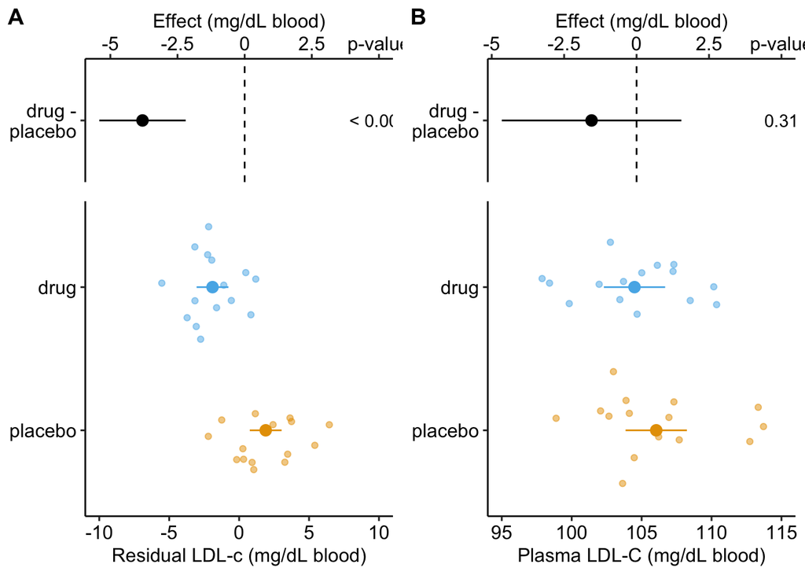

Effect of drug therapy on plasma LDL-C using residuals. Don’t do this!

1. The **age-adjusted means** in Figure @ref(covariate-fd-plot-cov)A are further apart (the difference is bigger) then the unadjusted means in Figure @ref(covariate-fd-plot-cov)B. This is seen in both the response and the effects components of the plot.
2. The spread of the residual LDL-C measures within each treatment level in Figure @ref(covariate-fd-plot-cov)A is less than the spread of the raw LDL-C measures in Figure @ref(covariate-fd-plot-cov)B.
3. The confidence interval of the effect (difference in means) is smaller using the adjusted model (Figure @ref(covariate-fd-plot-cov)A) than in the unadjusted model (Figure @ref(covariate-fd-plot-cov)B)
4. The *p*-value of the effect (difference in means) is smaller using the adjusted model (Figure @ref(covariate-fd-plot-cov)A) than in the unadjusted model (Figure @ref(covariate-fd-plot-cov)B)

These patterns are quantified by the Estimates and SEs of the coefficient table. Again, I show both for comparison. Can you match comparisons 1-4 above with the statistic in the coefficient table?

Coefficient table of two-step, “adjusted” model (adjusting for $age$):

```
##               Estimate Std. Error t value Pr(>|t|)  2.5 % 97.5 %
## (Intercept)      1.901      0.556   3.422    0.002  0.763  3.040
## treatmentdrug   -3.803      0.786  -4.840    0.000 -5.412 -2.193
```

```
##               Estimate Std. Error t value Pr(>|t|)   2.5 %  97.5 %
## (Intercept)    106.045      1.070  99.111    0.000 103.854 108.237
## treatmentdrug   -1.554      1.513  -1.027    0.313  -4.654   1.546
```

It is clear from the plots and the tables that this two-stage adjustment increases the precision of the estimates of the means and the differences in means by *eliminating the contribution of Age to the variance in LDL-C*.

3. The best practice for **adjusting for a covariate** (or the *statistical elimination of a covariate*) is to simply add the covariate to the linear model.

$$\begin{equation}
ldlc = \beta_0 + \beta_1 age + \beta_2 treatment_{drug} + \varepsilon
(\#eq:cov-cov)
\end{equation}$$

```
##               Estimate Std. Error t value Pr(>|t|)  2.5 % 97.5 %
## (Intercept)      75.60      3.260   23.20 2.28e-19 68.900  82.30
## age               1.26      0.133    9.47 4.46e-10  0.988   1.53
## treatmentdrug    -4.45      0.802   -5.55 6.94e-06 -6.090  -2.81
```

Again, compare the coefficient table from the model fit without the covariate.

```
##               Estimate Std. Error t value Pr(>|t|)  2.5 % 97.5 %
## (Intercept)     106.00       1.07   99.10 3.36e-37 104.00 108.00
## treatmentdrug    -1.55       1.51   -1.03 3.13e-01  -4.65   1.55
```

1. The adjusted effect is larger (-4.5 vs. -1.6)
2. The adjusted SE of the difference is smaller (0.8 vs. 1.5)
3. The adjusted CIs are narrower (-6.1, -2.8 vs. -4.7, 1.6)
4. The p-value of the adjusted difference is smaller (0.000007 vs. 0.31)

A plot of the model is

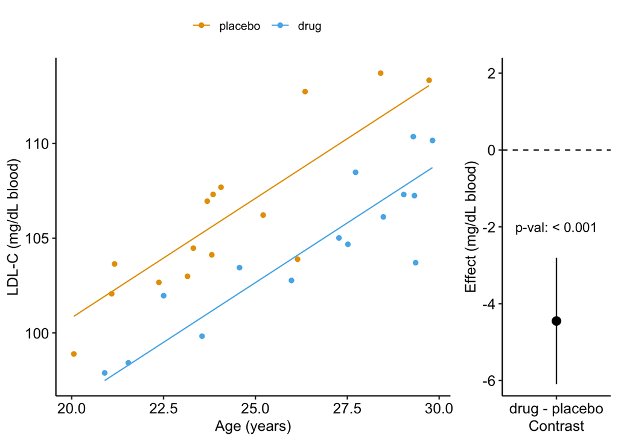

Effect of drug therapy, adjusted for age, on plasma LDL-C.

## Understanding a linear model with an added covariate – DoxDHCer data

[1-Deoxydihydroceramide causes anoxic death by impairing chaperonin-mediated protein folding](https://www.nature.com/articles/s42255-019-0123-y)

[Source data](https://www.nature.com/articles/s42255-019-0123-y#Sec38)

In this article, the researchers are investigating the effects of specific sphingolipids on hypoxia (low O2) in the heart. This hypoxia results in necrosis (death) of heart tissue. The researchers are specifically looking at the sphingolipid 1-deoxydihydroceramide (DoxDHCer), which is derived from 1-deoxysphinganine6 (DoxSa).

In the experiment for Figure 4h, the researchers measured the effect of three treatments on necrosis.

1. Vehicle – there is no “cardioprotection” from the hypoxia-producing sphingolipids. This is the “control”. We expect more necrotic area in this group. 2 Myriocin – a drug that inhibits the enzyme that iniates sphingolipid production. This drug should provide protection from the hypoxia-producing sphingolipids. We expect less necrotic area (or, cardioprotection) in this group.
2. Myriocin + DoxSa – DoxSa is the specific sphingolipid that the researchers believe cause the hypoxia/necrosis. The drug should inhibit the production of sphingolipids but the added DoxSa should reverses the protective effect of the drug. If there is a reversal of the protection, then this supports the hypothesis that DoxSa is the sphingolipid causing the hypoxia/necrosis.

The response ($Y$) variable is $area\_of\_necrosis$ – the measured “area” of the necrotic tissue (area is used here in the sense of “region” and not in the sense of length times width). The covariate is $area\_at\_risk$ – the area of heart tissue that is susceptible to necrosis.

### Fit the model

The verbal model with added covariate is

$area\_of\_necrosis \sim area\_at\_risk + treatment\;\;\;(\mathcal{M}_1)$.

which I’ll name model $\mathcal{M}_1$. To understand the model coefficients, it helps to expand model $\mathcal{M}_1$ into the full linear model.

$$\begin{equation}
area\_of\_necrosis = \beta_0 + \beta_1 area\_at\_risk + \beta_2 treatment_{myriosin} + \beta_3 treatment_{Myriocin\;+\;DoxSa} + \varepsilon
(\#eq:cov-fig4h-additive)
\end{equation}$$

The model includes parameters for the effects of area at risk ($\beta_1$), the myriosin treatment ($\beta_2$) and the myriosin + DoxSa treatment ($\beta_3$). I explain the interpretation of these effects in “Interpretation of the model coefficients” below.

```r
fig4h_m1 <- lm(area_of_necrosis ~ area_at_risk + treatment,
               data = fig4h)
```

### Plot the model

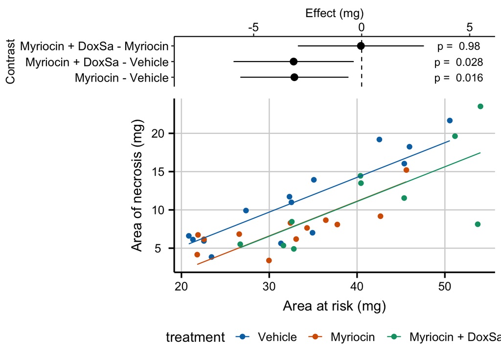

The effect of treatment on area of necrosis, adjusted for area of risk.

### Interpretation of the model coefficients

```r
fig4h_m1_coef <- cbind(coef(summary(fig4h_m1)),
      confint(fig4h_m1))
signif(fig4h_m1_coef, digits = 3)
```

```
##                           Estimate Std. Error t value Pr(>|t|)  2.5 %
## (Intercept)                 -3.890     2.1200   -1.83 7.63e-02 -8.220
## area_at_risk                 0.453     0.0587    7.73 8.28e-09  0.334
## treatmentMyriocin           -3.110     1.2300   -2.53 1.64e-02 -5.620
## treatmentMyriocin + DoxSa   -3.150     1.3700   -2.31 2.78e-02 -5.930
##                           97.5 %
## (Intercept)                0.436
## area_at_risk               0.573
## treatmentMyriocin         -0.611
## treatmentMyriocin + DoxSa -0.367
```

1. The estimate in the “(Intercept)” row ($b_0$) is the expected value of the reference (here, this is the “Vehicle” group) when $area\_at\_risk=0$. Using Figure @ref(fig:fig4h-m1-plot-model), this can be visualized as the value of $Y$ where the blue line (the regression line for the reference group) crosses the *y*-axis (at $X = 0$). This is not a meaningful estimate since the area at risk in all hearts is above zero.
2. The estimate in the “area_at_risk” row ($b_1$) is a common slope for all three regression lines. Some might refer to this slope as the “effect” of $area\_at\_risk$ on $area\_of\_necrosis$ but I recommend against using this causal language because the $area\_at\_risk$ is not randomly assigned – its purpose in *this* model (but not necessarily all linear models with an added covariate) is not for interpretation but for improving inference in the expimental treatment factor.
3. The estimate in the “treatmentMyriocin” row ($b_2$) is the effect of $Myriocin$ on $area\_of\_necrosis$ **conditional on** (or **adjusted for**) $area\_at\_risk$. A frequent phrase is “the estimate controlling for area at risk” but avoid this because “control” implies experimenter intervention and this is not true for $area\_at\_risk$. The value is the difference in the elevation of the regression line for the reference group and that for the Myriocin group. This difference is equal to the difference in conditional expectations at a specific value of the covariate.

$$\begin{equation}
b_2 = \mathrm{E}(area\_of\_necrosis|treatment = "Myriocin", X = x) - \mathrm{E}(area\_of\_necrosis|treatment = "Vehicle", X = x)
\end{equation}$$

4. The estimate in the “treatmentMyriocin + DoxSa” row ($b_3$) is the effect of $Myriocin + DoxSa$ on $area\_of\_necrosis$ **conditional on** (or **adjusted for**) $area\_at\_risk$. It’s interpretation is similar to that for $b_2$.

How do we summarize these interpretations given the motivating hypothesis? The results do not support the hypothesis. If DoxSa is one of the sphingolipids inducing hypoxia/necrosis, then we’d expect the Myriocin + DoxSa line to be elevated above the Myriocin line. But the coefficient table “tests” this prediction only indirectly. The explicit statistic for this prediction is the (Myriocin + DoxSa) - Myriocin contrast in the contrast table below.

### Everything adds up

Remember that everything adds up in a linear model. A regression line is a line of expected values (the expectation of $Y$ conditional on $X$). The point on the “Vehicle” line at $area\_of\_risk = 30$ is $b_0 + b_1 \cdot 30$. The point on the “Myriocin” line at $area\_of\_risk = 30$ is $b_0 + b_1 \cdot 30 + b_2$. And, the point on the “Myriocin + DoxSa” line at $area\_of\_risk = 30$ is $b_0 + b_1 \cdot 30 + b_3$. Understanding how the components of the linear model add up gives you phenomenonal cosmic power in statistical analysis.

### Interpretation of the estimated marginal means

```r
fig4h_m1_emm <- emmeans(fig4h_m1, specs = "treatment")
fig4h_m1_emm
```

```
##  treatment        emmean    SE df lower.CL upper.CL
##  Vehicle           11.98 0.839 32     10.3     13.7
##  Myriocin           8.87 0.916 32      7.0     10.7
##  Myriocin + DoxSa   8.83 1.045 32      6.7     11.0
##
## Confidence level used: 0.95
```

The values in the column “emmean” are the expected values of each group when (“conditional on”) $area\_at\_risk$ is equal to the mean $area\_at\_risk$.

### Interpretation of the contrasts

```r
fig4h_m1_pairs <- contrast(fig4h_m1_emm,
                           method = "revpairwise",
                           adjust = "none") %>%
  summary(infer = TRUE)
fig4h_m1_pairs
```

```
##  contrast                    estimate   SE df lower.CL upper.CL t.ratio
##  Myriocin - Vehicle           -3.1139 1.23 32    -5.62   -0.611 -2.534
##  Myriocin + DoxSa - Vehicle   -3.1485 1.37 32    -5.93   -0.367 -2.306
##  Myriocin + DoxSa - Myriocin  -0.0346 1.43 32    -2.95    2.881 -0.024
##  p.value
##  0.0164
##  0.0278
##  0.9809
##
## Confidence level used: 0.95
```

The values in the column “estimate” are the differences between the estimated marginal means in the estimated marginal means table. The first two contrasts are equal to the coefficients $b_2$ and $b_3$ in the coefficient table.

### Adding the covariate improves inference

Compare the effects in Model $\mathcal{M}_1$ (with the added covariate) to the effects in a linear model without the added covariate.

```
##                           Estimate Std. Error t value Pr(>|t|) 2.5 %
## (Intercept)                 11.200       1.39   8.070 2.60e-09  8.38
## treatmentMyriocin           -3.660       2.04  -1.790 8.26e-02 -7.82
## treatmentMyriocin + DoxSa    0.293       2.15   0.136 8.93e-01 -4.09
##                           97.5 %
## (Intercept)               14.000
## treatmentMyriocin          0.499
## treatmentMyriocin + DoxSa  4.670
```

Inference from these two models is very different. From the model adjusting for area at risk (Model $\mathcal{M}_1$), we would conclude “Unexpectedly, the estimated Myriocin + DoxSa effect (-3.2 mg, 95% CI: -5.9, -0.4) is effectively as big as the Myriocin alone effect.” By contrast, using the model without the covariate, we would conclude “Relative to the Myriocin effect, the estimated Myriocin + DoxSa effect is small (.29 mg), and there is large uncertainty in its direction and magnitude (95% CI: -4.1, 4.7).” (Note that the authors published a different conclusion to either of these. I cannot recover the results leading to their conclusion using the methods published by the authors.)

## Understanding interaction effects with covariates

### Fit the model

When we add a continuous covariate to a model we sometimes want to model the **interaction** with the categorical factor variable. An interaction effect represents how the effect of one variable changes given the level of a second variable. The verbal model with an added interaction effect is

$area\_of\_necrosis \sim area\_at\_risk + treatment + area\_at\_risk \times treatment\;\;\;(\mathcal{M}_2)$

which I’ll refer to as Model $\mathcal{M}_2$. To understand the model coefficients, it helps to expand this into the full linear model.

$$\begin{align}
area\_of\_necrosis = \beta_0 &+ \beta_1 area\_at\_risk + \beta_2 treatment_{myriosin} + \beta_3 treatment_{Myriocin\;+\;DoxSa}\\
&+ \beta_4 area\_at\_risk \cdot treatment_{myriosin}\\
&+ \beta_5 area\_at\_risk \cdot treatment_{Myriocin\;+\;DoxSa}\\
&+ \varepsilon
(\#eq:cov-fig4h-interaction)
\end{align}$$

```r
# see working in R to understand this model formula
fig4h_m2 <- lm(area_of_necrosis ~ area_at_risk*treatment,
               data = fig4h)
```

### Plot the model with interaction effect

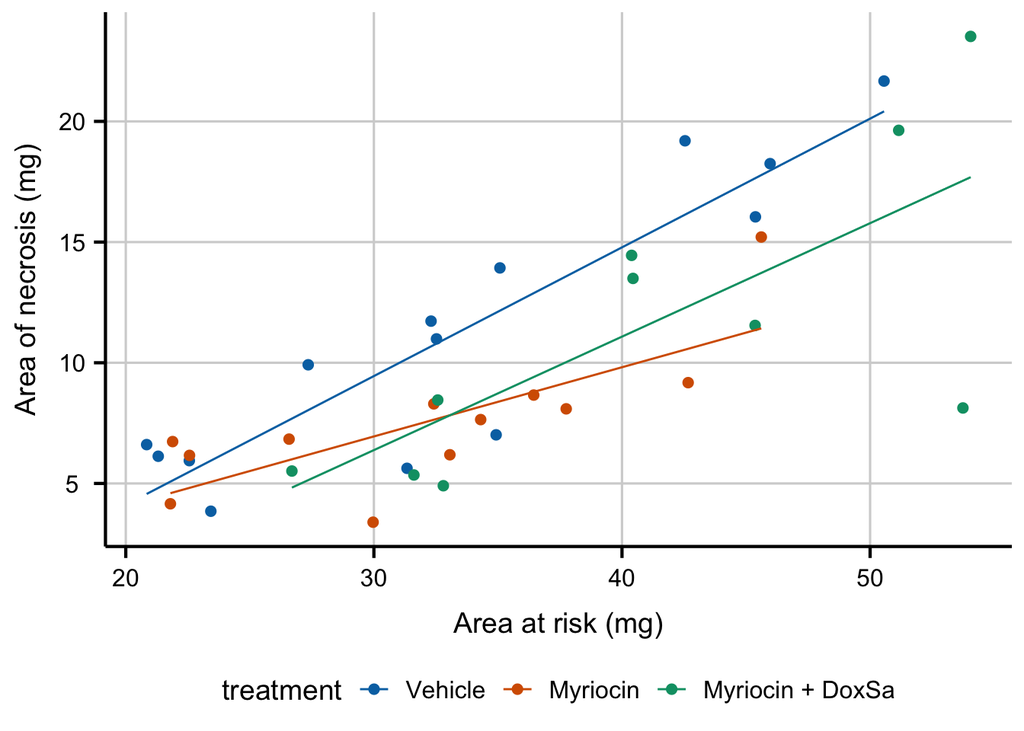

The effect of treatment on area of necrosis, adjusted for area of risk.

### Interpretation of the model coefficients

```r
fig4h_m2_coef <- cbind(coef(summary(fig4h_m2)),
      confint(fig4h_m2))
round(fig4h_m2_coef[,c(1,2)], digits = 2)
```

```
##                                        Estimate Std. Error
## (Intercept)                               -6.55       3.01
## area_at_risk                               0.53       0.09
## treatmentMyriocin                          4.90       4.90
## treatmentMyriocin + DoxSa                 -1.17       5.28
## area_at_risk:treatmentMyriocin            -0.25       0.15
## area_at_risk:treatmentMyriocin + DoxSa    -0.06       0.14
```

Interaction effects are *differences in slopes* (this is also true with interactions between two factor variables, even though we usually describe this as “differences in differences”) and these difference are easily seen by inspection of a plot similar to that in Figure @ref(fig:fig4h-m2-plot-model). The bigger the interaction, the less parallel the regression line.

### What is the effect of a treatment, if interactions are modeled? – it depends.

A very useful way to remember what an interaction *is* is “it depends”. What is the effect of Myriocin on area at risk? With an interaction term in the linear model, the answer is “it depends”. It depends on the level of $area\_at\_risk$. At small values of area at risk, the effect of Myriocin is very small. At large values of area at risk, the effect of Myriocin is large. Likewise, what is the effect of area at risk on necrosis? It depends (if interactions are modeled). It depends on the level of treatment, for example the effect in the Myriocin group is smaller (a smaller slope) than the effect in the Vehicle group. “It depends” is the hallmark of interactions – the effect of one variable on the outcome depends on the level of a second variable.

### Which model do we use, $\mathcal{M}_1$ or $\mathcal{M}_2$?

The answer to this question depends partly on our goals. If we are explicitly interested in measuring an interaction effect (perhaps some theory predicts an positive interaction) then we would necesarily add interaction effects to the model. But if we are interested in estimating a treatment effect conditional on a covariate, then we don’t include the interaction. Remember that a purpose of initial explorations of data (“Step 2 – examine the data”) is to help decide which model to specify in the model formula. If an initial plot shows large interactions between treatment levels and the covariate, then adjusting for the covariate won’t work, or at least won’t work without additional complexity to the interpretation. “Large interactions” of course raises the question, how large is too larege to ignore interactions? Many textbooks in biostatistics recommend using an interaction *p*-value to make this decision. I disagree. There is no objective answer to the question. We lose information with all models – that is what we do in science. It is up to the researcher to be transparent with all decisions. If an additive (no interactions) model is used to condition on (adjust for) a covariate, the researcher should use the supplement to plot the model with interactions as evidence of why this decision is reasonable.

## Understanding ANCOVA tables

## Working in R

### Fitting the model

For an additive model, add the covariate to the model formula using the `+` operator. The order of the variables doesn’t matter (the right-hand-side of the model formula could be `treatment + area_at_risk`).

```r
m1 <- lm(area_of_necrosis ~ area_at_risk + treatment, data = fig4h)
```

For an nonadditive model with interactions, add the covariate to the model formula using the `*` operator. `~ area_at_risk * treatment` is a shortcut to the full model formula, which is `1 + area_at_risk + treatment + area_at_risk * treatment`. R expands the short formula to the full formula automatically. Again, the order of the variables doesn’t matter (the right-hand-side of the model formula could be `treatment * area_at_risk`).

```r
m1 <- lm(area_of_necrosis ~ area_at_risk * treatment, data = fig4h)
```

### Plotting the model

#### A response-effects plot using ggplot2

```r
m1 <- lm(area_of_necrosis ~ area_at_risk + treatment, data = fig4h)
b <- coef(m1)

groups <- levels(fig4h$treatment)
line_data <- fig4h[, .(min_x = min(area_at_risk),
                       max_x = max(area_at_risk)), by = treatment]
line_data[, dummy1 := ifelse(treatment == "Myriocin", 1, 0)]
line_data[, dummy2 := ifelse(treatment == "Myriocin + DoxSa", 1, 0)]

line_data[, y_min := b[1] + b[2]*min_x + b[3]*dummy1 + b[4]*dummy2]
line_data[, y_max := b[1] + b[2]*max_x + b[3]*dummy1 + b[4]*dummy2]

gg_response <- ggplot(data = fig4h,
                      aes(x = area_at_risk,
                          y = area_of_necrosis,
                          color = treatment)) +
  # points
  geom_point(size = 2) +

  geom_segment(data = line_data,
               aes(x = min_x,
                   y = y_min,
                   xend = max_x,
                   yend = y_max)) +
  scale_color_manual(values = pal_ito_seven) +
  ylab("Area of necrosis (mg)") +
  xlab("Area at risk (mg)") +
  theme_grid() +
  theme(legend.position="bottom") +

  NULL
#gg_response
```

```r
m1_emm <- emmeans(m1, specs = "treatment")
m1_pairs <- contrast(m1_emm,
                     method = "revpairwise",
                     adjust = "none") %>%
  summary(infer = TRUE) %>%
  data.table()
# pvalString is from package lazyWeave
m1_pairs[ , p_pretty := pvalString(p.value)]
# also create a column with "p-val: "
m1_pairs[ , pval_pretty := paste("p = ", p_pretty)]

contrast_order <- m1_pairs[, contrast]
m1_pairs[, contrast := factor(contrast, contrast_order)]

gg_effect <- ggplot(data = m1_pairs,
                    aes(y = contrast,
                        x = estimate)) +
  # confidence level of effect
  geom_errorbar(aes(xmin = lower.CL,
                    xmax = upper.CL),
                width = 0,
                color = "black") +
  # estimate of effect
  geom_point(size = 3) +

  # draw a line at effect = 0
  geom_vline(xintercept = 0, linetype = 2) +

  # p-value. The y coordinates are set by eye
  annotate(geom = "text",
           label = m1_pairs$pval_pretty,
           y = 1:3,
           x = 4.5) +

  # x-axis label and aesthetics
  xlab("Effect (mg)") +
  ylab("Contrast") +
  coord_cartesian(xlim = c(-8,5.5)) +
  scale_x_continuous(position="top") +

  theme_pubr() +
  # theme(axis.title.x = element_blank()) +

  NULL
# gg_effect

gg <- plot_grid(gg_effect,
                gg_response,
                nrow=2,
                align = "v",
                axis = "rl",
                rel_heights = c(0.35, 1)
                )
```

[output not shown]

[output cut: 70 more lines]

[output not shown]

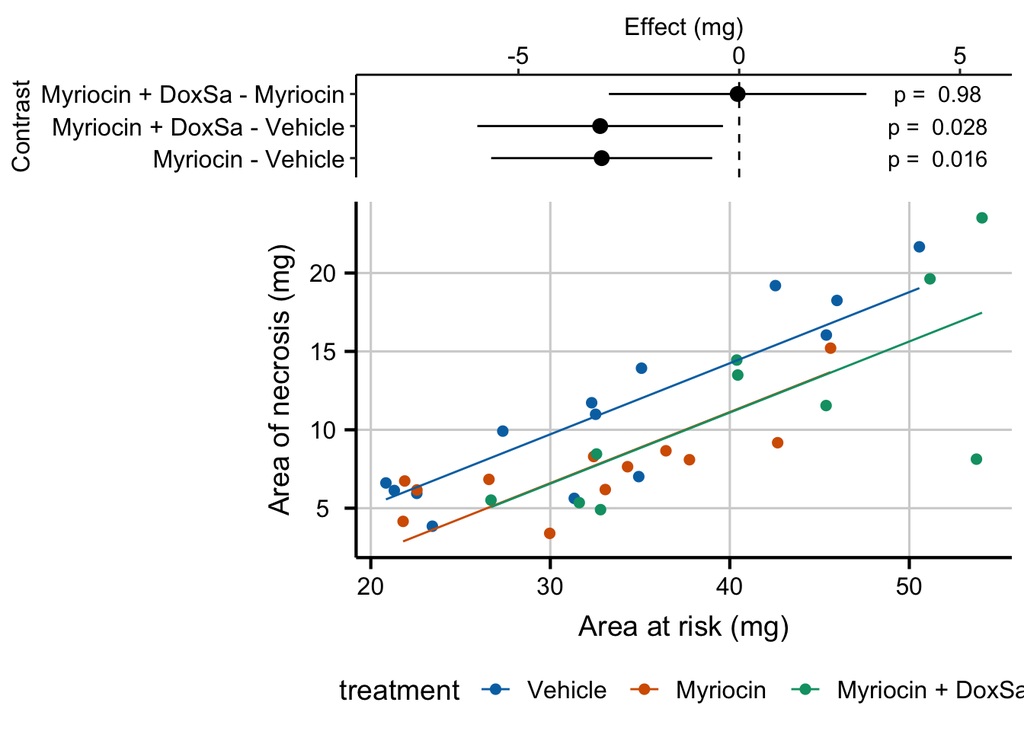

```r
gg
```

## Best practices

### Do not use a ratio of part:whole as a response variable – instead add the denominator as a covariate

### Do not use change from baseline as a response variable – instead add the baseline measure as a covariate

It is common to measure the outcome variable ($Y$) both before and after the experimental treatments are applied and then compare the pre-post *change* in $Y$ in response to the treatment using a $t$-test or ANOVA using this linear model

$$\begin{equation}
Y_{post}-Y_{pre} = \beta_0 + \beta_1 Treatment + \varepsilon
(\#eq:cov-change-score)
\end{equation}$$

**Don’t do this**. Instead, add the pre-treatment measure into the model as a covariate.

$$\begin{equation}
Y_{post} = \beta_0 + \beta_1 Y_{pre} + \beta_2 Treatment + \varepsilon
(\#eq:ancova-4)
\end{equation}$$

where $Treatment$ is a dummy variable for a two-level factor. A pre-treatment measure ($Y_{pre}$) is often called the *baseline* measure. The change in $Y$ ($\Delta Y = Y{post} - Y_{pre}$) is sometimes called a change score or gain score. If you really want to estimate the treatment effect on the change from pre-treatment value to post-treatment value, then use model @ref(eq:ancova-4) with $\Delta Y$ as the response – the $p$-value will be precisely the same (the estimate and SE will differ of course because the response variable is different).

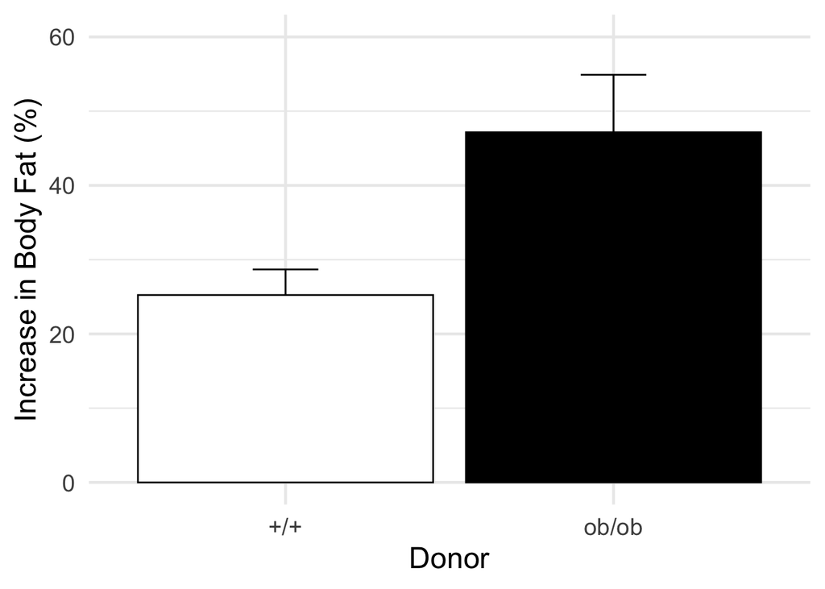

Figure 3c of Turnbaugh *et al* 2006. This figure was generated with simulated data matching the summary statistics given in Turnbaugh *et al* 2006

That looks like a big difference, with the mice from the obese-donor treatment level gaining much more fat than the mice from the lean-donor treatment level. Turnbaugh et al. used a simple t-test of this percent change to test the effect of the *ob/ob* treatment. The linear model underneath this $t$-test is

$$\begin{equation}
percent\_change\_fat = \beta_0 + \beta_1 obese + \varepsilon
\end{equation}$$

where $percent\_change\_fat$ is the percent change in fat from baseline and $obese$ is a dummy variable with *ob/ob* $= 1$. The percent change in fat is $\frac{fat_{post} - fat_{pre}}{fat_{pre}} \times 100$, so is a function of the change score $\Delta_{fat} = fat_{post} - fat_{pre}$.

The model coefficients are

```
##                Estimate Std. Error  t value     Pr(>|t|)
## (Intercept)    25.24015   5.627515 4.485134 0.0003259533
## treatmentob/ob 21.92156   8.176589 2.681016 0.0157879742
```

```
##                    2.5 %   97.5 %
## (Intercept)    13.367137 37.11317
## treatmentob/ob  4.670468 39.17266
```

Or, the increase in fat in the obese-treated mice was 21.9% (95%CI: 4.7, 39.2%, $p=0.016$) greater than the increase in lean-treated mice. This result, if generally verified with replication and rigorous probing, would have spectacular implications for human health.

### Regression to the mean in words

Regression to the mean is the phenomenon that if an extreme value is sampled, the next sample will likely be less extreme. This makes sense, if you randomly sample a single human male and that individual is 6’10" (about 4 standard deviations above the mean), the next human you randomly sample will almost certainly be closer to the mean human male. Or, if you randomly sample five human males and the mean height in the group is 5’1" (about 3 standard deviations below the mean), the next sample of five human males that you measure will almost certainly be closer to the mean human male.

How does regression to the mean apply to the analysis of change scores in a pre-post experiment, like the mouse fecal transplant study? In a pre-post experiment, subjects are randomized to treatment group. The response is measured at baseline and again at the conclusion of the experiment. Despite random treatment assignment, the mean fat weight of the *ob/ob* group at baseline was 1.2 standard deviations smaller than that of the *+/+* group. If there is no treatment effect, what is the expected difference at the end?

To answer this, we need to know how an individual’s fat weight at the end is related to its fat weight at baseline. An individual’s final fat is dependent on its initial fat if factors that contribute to the measurement of fat are the same at baseline and the end. For example, if an individual has relatively high metabolism both at baseline and at the end, then that individual might have relatively low fat at baseline and at the end. This dependence of final value on baseline value is quantified by the correlation between the two measures. This correlation is $\rho$ (the greek letter rho). Factors that change over the duration of the experiment, including random measurement error, cause the correlation to be less than one. The two extremes of this correlatioun, and the expected difference in fat weight at the end are:

1. $\rho=0$ – if an individual’s final fat is independent of its initial fat then we expect the difference at end to be zero.
2. $\rho=1$ – if an individuals’s final fat is entirely dependent on its initial fat, then we’d expect the mean fat weight of the *ob/ob* group to be 1.2 standard deviations smaller than that of the *+/+* group, exactly as it was at baseline.

Regression to the mean happens when $\rho < 1$ and its consequences increase as $\rho$ goes to zero. What is meant by “consequences”?

The fat weight of the *ob/ob* group at baseline is 1.2 standard deviations smaller than that of the *+/+* group. If $\rho=0$, then we’d expect the difference between mean fat weight at the end of the experiment to be zero. *Given the starting differences in mean weight*, to get to zero difference at the end, the *ob/ob* mice would have to gain more fat weight than the *+/+* mice. Since the expectation of the mean difference at the end is zero the expectation of the change score *must be bigger for the ob/ob mice than for the +/+ mice*. That is the expectation of the *difference* in change score is conditional on (or “a function of”) the difference in fat weight at baseline.

### Regression to the mean in pictures

Let’s simulate this to pump our intuition about regression to the mean and its consequences on pre-post experiments.

1. randomly sample a normal distribution as the “initial weight” and randomly assign to treatment class
2. let the final weight have some correlation ($\rho$) with the initial weight. Some correlation should make sense – we expect a mouse that has more fat than average at the start of the experiment to also have more fat than average at the end of the experiment. Run the experiment at different values of this correlation to see how it effects regression to the mean.
3. Do not add a treatment effect. We want to explore the behavior of the nill null hypothesis.

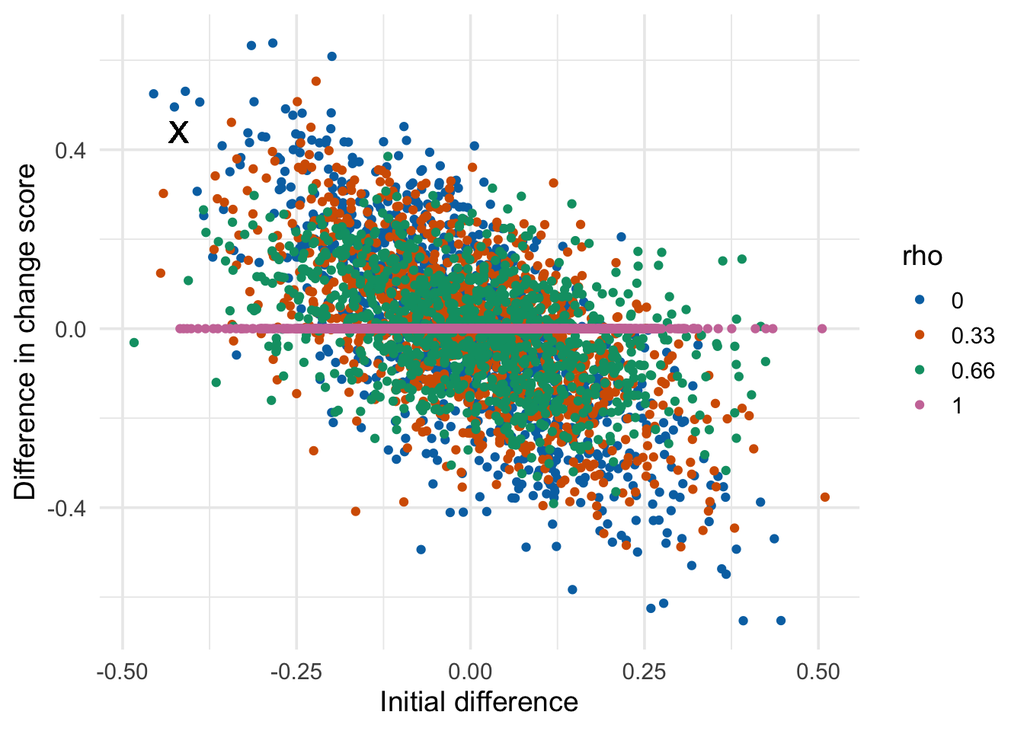

Effect of initial difference in weight on the difference in change score. Increased initial difference in weight results in an increased differences in change score between treatment and control. Four different values of *rho* (the correlation between initial and final weights) were simulated. Only when *rho*=1 is there no influence of initial difference, because whatever differences occur at baseline will be perfectly preserved in the final measure. The X gives the values in the original Turnbaugh data

$$\begin{equation}
\mathrm{E}(\Delta Y_{ob/ob} - \Delta Y_{+/+}) = 0
\end{equation}$$

but the change conditional on baseline is not zero

$$\begin{equation}
\mathrm{E}(\Delta Y_{ob/ob} - \Delta Y_{+/+}) \ne 0
\end{equation}$$

Instead, the conditional expectation is a function of the difference at baseline. If the initial difference in weight happens to be unusually large and negative, the expected difference in change score is unusually positive. This non-zero expectation means that the estimate of the treatment effect is **conditionally biased** for any model that does not include the baseline fat weight as a covariate. And, from a frequentist perspective, the Type I error for a test of a difference in $\Delta Y$ is strongly dependent on the initial difference in weight.

The big X in the plot indicates the difference at baseline and difference in $\Delta Y$ for the original fecal transplant study. The difference in $Delta Y$ is unusually positive (about .6% of the $|\delta Y|$ are larger) but very close to the expected value given the unusually large, negative difference at baseline. In other words, the probability of the data, or more extreme than the data, is not 0.006 but something larger and perhaps, much larger (the computed value depends on the observed $\rho$. From, the plot, the X is very unusual if $\rho=1$, pretty unusual if $\rho=0.66$, but pretty common if $\rho=0.33$ or if $\rho=0$).

### Do not use percent change, believing that percents account for effects of initial weights

Some researchers mistakenly believe that a $t$-test of percent change automatically adjusts for effects in initial weight, since this initial weight is in the denominator of the percent. This is wrong. The dependency of the difference in change between treatments on the initial difference between treatments is more severe if change is measured as a percent, because the numerator (the change score) is expected to be larger if the denominator is smaller (initial measure). Using the simulated data from above, here is this dependency.

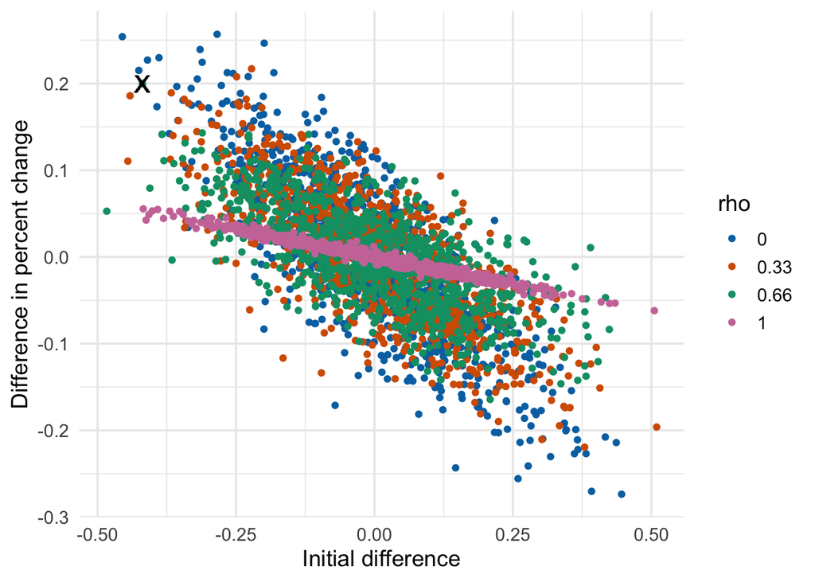

Effect of initial difference in weight on the difference in percent change. Increased initial difference in weight results in an increased differences in Percent change between treatment and control. Four different values of *rho* (the correlation between initial and final weights) were simulated. Note there is no value of *rho* where the difference in percent change is independent of the initial difference. The X gives the values in the original Turnbaugh data.

### Do not “test for balance” of baseline measures

A test of the null hypothesis of no difference in mean at baseline is a “test for balance.” Researchers frequently test for balance at baseline and use the *p*-value of the test to decide the next step: 1) if $p > 0.05$, conclude that the pre-treatment means “do not differ” and use something like a simple *t* test of the post-treatment means, 2) if $p < 0.05$, then use the change score, or the percent change, as the response in a simple *t*-test, or 3) if $p < 0.05$, then use use a linear model with the pre-treatment value as a covariate. Here, and in general, hypothesis tests used to decide which of several ways to proceed do not make sense. First, a null-hypothesis significance test cannot tell you that there is “no difference” – this is not what null-hypothesis tests do. Second, any $p$-value after the initial test isn’t strictly valid as it does not take into account this decision step, but this is minor. Third, **it doesn’t matter**; there will always be some difference in the actual means of the initial measures and, consequently, the conditional expectation of the final measures, or change in measures, or percent change will be dependent on this initial difference. So, if one has initial measures, one should use an linear model that adjusts for baseline measures to estimate the treatment effect in pre-post designs. And, if one isn’t planning on taking an initial measure, then maybe you should, because the initial measure used in a linear model allows a better estimate of the treatment effect, as discussed above in Adding covariates can increases the precision of the effect of interest.

## Best practices 2: Use a covariate instead of normalizing a response